# R Notebook

ManikumarKR

# **1 The Goal**

1. How do annual members and casual riders use Cyclistic bikes differently?
2. Why would casual riders buy Cyclistic annual memberships?
3. How can Cyclistic use digital media to influence casual riders to become members?

# The **Dataset**

# Installing packages

```r
install.packages("tidyverse")
install.packages("lubridate")
install.packages("ggplot2")
```

# Loading packages

```r
library(tidyverse)
library(lubridate)
library(ggplot2)
library(dbplyr)
```

# importing data

### importing all 12 months dataset.

```r
one_five <- read.csv("202105-divvy-tripdata.csv")
one_six <- read.csv("202106-divvy-tripdata.csv")
one_seven <- read.csv("202107-divvy-tripdata.csv")
one_eight <- read.csv("202108-divvy-tripdata.csv")
one_nine <- read.csv("202109-divvy-tripdata.csv")
one_ten <- read.csv("202110-divvy-tripdata.csv")
one_eleven <- read.csv("202111-divvy-tripdata.csv")
one_twelve <- read.csv("202112-divvy-tripdata.csv")
two_one <- read.csv("202201-divvy-tripdata.csv")
two_two <- read.csv("202202-divvy-tripdata.csv")
two_three <- read.csv("202203-divvy-tripdata.csv")
two_four <- read.csv("202204-divvy-tripdata.csv")
```

### getting familar with dataset

```r
colnames(one_five)
 colnames(one_six)
 colnames(one_seven)
 colnames(one_eight)
 colnames(one_nine)
 colnames(one_ten)
 colnames(one_ten)
 colnames(one_eleven)
 colnames(one_twelve)
 colnames(two_one)
 colnames(two_two)
 colnames(two_three)
 colnames(two_four)
```

```r
str(one_five)
```

```
'data.frame':   531633 obs. of  13 variables:
 $ ride_id           : chr  "C809ED75D6160B2A" "DD59FDCE0ACACAF3" "0AB83CB88C43EFC2" "7881AC6D39110C60" ...
 $ rideable_type     : chr  "electric_bike" "electric_bike" "electric_bike" "electric_bike" ...
 $ started_at        : chr  "2021-05-30 11:58:15" "2021-05-30 11:29:14" "2021-05-30 14:24:01" "2021-05-30 14:25:51" ...
 $ ended_at          : chr  "2021-05-30 12:10:39" "2021-05-30 12:14:09" "2021-05-30 14:25:13" "2021-05-30 14:41:04" ...
 $ start_station_name: chr  "" "" "" "" ...
 $ start_station_id  : chr  "" "" "" "" ...
 $ end_station_name  : chr  "" "" "" "" ...
 $ end_station_id    : chr  "" "" "" "" ...
 $ start_lat         : num  41.9 41.9 41.9 41.9 41.9 ...
 $ start_lng         : num  -87.6 -87.6 -87.7 -87.7 -87.7 ...
 $ end_lat           : num  41.9 41.8 41.9 41.9 41.9 ...
 $ end_lng           : num  -87.6 -87.6 -87.7 -87.7 -87.7 ...
 $ member_casual     : chr  "casual" "casual" "casual" "casual" ...
```

```r
 str(one_six)
```

```
'data.frame':   729595 obs. of  13 variables:
 $ ride_id           : chr  "99FEC93BA843FB20" "06048DCFC8520CAF" "9598066F68045DF2" "B03C0FE48C412214" ...
 $ rideable_type     : chr  "electric_bike" "electric_bike" "electric_bike" "electric_bike" ...
 $ started_at        : chr  "2021-06-13 14:31:28" "2021-06-04 11:18:02" "2021-06-04 09:49:35" "2021-06-03 19:56:05" ...
 $ ended_at          : chr  "2021-06-13 14:34:11" "2021-06-04 11:24:19" "2021-06-04 09:55:34" "2021-06-03 20:21:55" ...
 $ start_station_name: chr  "" "" "" "" ...
 $ start_station_id  : chr  "" "" "" "" ...
 $ end_station_name  : chr  "" "" "" "" ...
 $ end_station_id    : chr  "" "" "" "" ...
 $ start_lat         : num  41.8 41.8 41.8 41.8 41.8 ...
 $ start_lng         : num  -87.6 -87.6 -87.6 -87.6 -87.6 ...
 $ end_lat           : num  41.8 41.8 41.8 41.8 41.8 ...
 $ end_lng           : num  -87.6 -87.6 -87.6 -87.6 -87.6 ...
 $ member_casual     : chr  "member" "member" "member" "member" ...
```

```r
 str(one_seven)
```

```
'data.frame':   822410 obs. of  13 variables:
 $ ride_id           : chr  "0A1B623926EF4E16" "B2D5583A5A5E76EE" "6F264597DDBF427A" "379B58EAB20E8AA5" ...
 $ rideable_type     : chr  "docked_bike" "classic_bike" "classic_bike" "classic_bike" ...
 $ started_at        : chr  "2021-07-02 14:44:36" "2021-07-07 16:57:42" "2021-07-25 11:30:55" "2021-07-08 22:08:30" ...
 $ ended_at          : chr  "2021-07-02 15:19:58" "2021-07-07 17:16:09" "2021-07-25 11:48:45" "2021-07-08 22:23:32" ...
 $ start_station_name: chr  "Michigan Ave & Washington St" "California Ave & Cortez St" "Wabash Ave & 16th St" "California Ave & Cortez St" ...
 $ start_station_id  : chr  "13001" "17660" "SL-012" "17660" ...
 $ end_station_name  : chr  "Halsted St & North Branch St" "Wood St & Hubbard St" "Rush St & Hubbard St" "Carpenter St & Huron St" ...
 $ end_station_id    : chr  "KA1504000117" "13432" "KA1503000044" "13196" ...
 $ start_lat         : num  41.9 41.9 41.9 41.9 41.9 ...
 $ start_lng         : num  -87.6 -87.7 -87.6 -87.7 -87.7 ...
 $ end_lat           : num  41.9 41.9 41.9 41.9 41.9 ...
 $ end_lng           : num  -87.6 -87.7 -87.6 -87.7 -87.7 ...
 $ member_casual     : chr  "casual" "casual" "member" "member" ...
```

```r
 str(one_eight)
```

```
'data.frame':   804352 obs. of  13 variables:
 $ ride_id           : chr  "99103BB87CC6C1BB" "EAFCCCFB0A3FC5A1" "9EF4F46C57AD234D" "5834D3208BFAF1DA" ...
 $ rideable_type     : chr  "electric_bike" "electric_bike" "electric_bike" "electric_bike" ...
 $ started_at        : chr  "2021-08-10 17:15:49" "2021-08-10 17:23:14" "2021-08-21 02:34:23" "2021-08-21 06:52:55" ...
 $ ended_at          : chr  "2021-08-10 17:22:44" "2021-08-10 17:39:24" "2021-08-21 02:50:36" "2021-08-21 07:08:13" ...
 $ start_station_name: chr  "" "" "" "" ...
 $ start_station_id  : chr  "" "" "" "" ...
 $ end_station_name  : chr  "" "" "" "" ...
 $ end_station_id    : chr  "" "" "" "" ...
 $ start_lat         : num  41.8 41.8 42 42 41.8 ...
 $ start_lng         : num  -87.7 -87.7 -87.7 -87.7 -87.6 ...
 $ end_lat           : num  41.8 41.8 42 42 41.8 ...
 $ end_lng           : num  -87.7 -87.6 -87.7 -87.7 -87.6 ...
 $ member_casual     : chr  "member" "member" "member" "member" ...
```

```r
 str(one_nine)
```

```
'data.frame':   756147 obs. of  13 variables:
 $ ride_id           : chr  "9DC7B962304CBFD8" "F930E2C6872D6B32" "6EF72137900BB910" "78D1DE133B3DBF55" ...
 $ rideable_type     : chr  "electric_bike" "electric_bike" "electric_bike" "electric_bike" ...
 $ started_at        : chr  "2021-09-28 16:07:10" "2021-09-28 14:24:51" "2021-09-28 00:20:16" "2021-09-28 14:51:17" ...
 $ ended_at          : chr  "2021-09-28 16:09:54" "2021-09-28 14:40:05" "2021-09-28 00:23:57" "2021-09-28 15:00:06" ...
 $ start_station_name: chr  "" "" "" "" ...
 $ start_station_id  : chr  "" "" "" "" ...
 $ end_station_name  : chr  "" "" "" "" ...
 $ end_station_id    : chr  "" "" "" "" ...
 $ start_lat         : num  41.9 41.9 41.8 41.8 41.9 ...
 $ start_lng         : num  -87.7 -87.6 -87.7 -87.7 -87.7 ...
 $ end_lat           : num  41.9 42 41.8 41.8 41.9 ...
 $ end_lng           : num  -87.7 -87.7 -87.7 -87.7 -87.7 ...
 $ member_casual     : chr  "casual" "casual" "casual" "casual" ...
```

```r
 str(one_ten)
```

```
'data.frame':   631226 obs. of  13 variables:
 $ ride_id           : chr  "620BC6107255BF4C" "4471C70731AB2E45" "26CA69D43D15EE14" "362947F0437E1514" ...
 $ rideable_type     : chr  "electric_bike" "electric_bike" "electric_bike" "electric_bike" ...
 $ started_at        : chr  "2021-10-22 12:46:42" "2021-10-21 09:12:37" "2021-10-16 16:28:39" "2021-10-16 16:17:48" ...
 $ ended_at          : chr  "2021-10-22 12:49:50" "2021-10-21 09:14:14" "2021-10-16 16:36:26" "2021-10-16 16:19:03" ...
 $ start_station_name: chr  "Kingsbury St & Kinzie St" "" "" "" ...
 $ start_station_id  : chr  "KA1503000043" "" "" "" ...
 $ end_station_name  : chr  "" "" "" "" ...
 $ end_station_id    : chr  "" "" "" "" ...
 $ start_lat         : num  41.9 41.9 41.9 41.9 41.9 ...
 $ start_lng         : num  -87.6 -87.7 -87.7 -87.7 -87.7 ...
 $ end_lat           : num  41.9 41.9 41.9 41.9 41.9 ...
 $ end_lng           : num  -87.6 -87.7 -87.7 -87.7 -87.7 ...
 $ member_casual     : chr  "member" "member" "member" "member" ...
```

```r
 str(one_eleven)
```

```
'data.frame':   359978 obs. of  13 variables:
 $ ride_id           : chr  "7C00A93E10556E47" "90854840DFD508BA" "0A7D10CDD144061C" "2F3BE33085BCFF02" ...
 $ rideable_type     : chr  "electric_bike" "electric_bike" "electric_bike" "electric_bike" ...
 $ started_at        : chr  "2021-11-27 13:27:38" "2021-11-27 13:38:25" "2021-11-26 22:03:34" "2021-11-27 09:56:49" ...
 $ ended_at          : chr  "2021-11-27 13:46:38" "2021-11-27 13:56:10" "2021-11-26 22:05:56" "2021-11-27 10:01:50" ...
 $ start_station_name: chr  "" "" "" "" ...
 $ start_station_id  : chr  "" "" "" "" ...
 $ end_station_name  : chr  "" "" "" "" ...
 $ end_station_id    : chr  "" "" "" "" ...
 $ start_lat         : num  41.9 42 42 41.9 41.9 ...
 $ start_lng         : num  -87.7 -87.7 -87.7 -87.8 -87.6 ...
 $ end_lat           : num  42 41.9 42 41.9 41.9 ...
 $ end_lng           : num  -87.7 -87.7 -87.7 -87.8 -87.6 ...
 $ member_casual     : chr  "casual" "casual" "casual" "casual" ...
```

```r
 str(one_twelve)
```

```
'data.frame':   247540 obs. of  13 variables:
 $ ride_id           : chr  "46F8167220E4431F" "73A77762838B32FD" "4CF42452054F59C5" "3278BA87BF698339" ...
 $ rideable_type     : chr  "electric_bike" "electric_bike" "electric_bike" "classic_bike" ...
 $ started_at        : chr  "2021-12-07 15:06:07" "2021-12-11 03:43:29" "2021-12-15 23:10:28" "2021-12-26 16:16:10" ...
 $ ended_at          : chr  "2021-12-07 15:13:42" "2021-12-11 04:10:23" "2021-12-15 23:23:14" "2021-12-26 16:30:53" ...
 $ start_station_name: chr  "Laflin St & Cullerton St" "LaSalle Dr & Huron St" "Halsted St & North Branch St" "Halsted St & North Branch St" ...
 $ start_station_id  : chr  "13307" "KP1705001026" "KA1504000117" "KA1504000117" ...
 $ end_station_name  : chr  "Morgan St & Polk St" "Clarendon Ave & Leland Ave" "Broadway & Barry Ave" "LaSalle Dr & Huron St" ...
 $ end_station_id    : chr  "TA1307000130" "TA1307000119" "13137" "KP1705001026" ...
 $ start_lat         : num  41.9 41.9 41.9 41.9 41.9 ...
 $ start_lng         : num  -87.7 -87.6 -87.6 -87.6 -87.7 ...
 $ end_lat           : num  41.9 42 41.9 41.9 41.9 ...
 $ end_lng           : num  -87.7 -87.7 -87.6 -87.6 -87.6 ...
 $ member_casual     : chr  "member" "casual" "member" "member" ...
```

```r
 str(two_one)
```

```
'data.frame':   103770 obs. of  13 variables:
 $ ride_id           : chr  "C2F7DD78E82EC875" "A6CF8980A652D272" "BD0F91DFF741C66D" "CBB80ED419105406" ...
 $ rideable_type     : chr  "electric_bike" "electric_bike" "classic_bike" "classic_bike" ...
 $ started_at        : chr  "2022-01-13 11:59:47" "2022-01-10 08:41:56" "2022-01-25 04:53:40" "2022-01-04 00:18:04" ...
 $ ended_at          : chr  "2022-01-13 12:02:44" "2022-01-10 08:46:17" "2022-01-25 04:58:01" "2022-01-04 00:33:00" ...
 $ start_station_name: chr  "Glenwood Ave & Touhy Ave" "Glenwood Ave & Touhy Ave" "Sheffield Ave & Fullerton Ave" "Clark St & Bryn Mawr Ave" ...
 $ start_station_id  : chr  "525" "525" "TA1306000016" "KA1504000151" ...
 $ end_station_name  : chr  "Clark St & Touhy Ave" "Clark St & Touhy Ave" "Greenview Ave & Fullerton Ave" "Paulina St & Montrose Ave" ...
 $ end_station_id    : chr  "RP-007" "RP-007" "TA1307000001" "TA1309000021" ...
 $ start_lat         : num  42 42 41.9 42 41.9 ...
 $ start_lng         : num  -87.7 -87.7 -87.7 -87.7 -87.6 ...
 $ end_lat           : num  42 42 41.9 42 41.9 ...
 $ end_lng           : num  -87.7 -87.7 -87.7 -87.7 -87.6 ...
 $ member_casual     : chr  "casual" "casual" "member" "casual" ...
```

```r
 str(two_two)
```

```
'data.frame':   115609 obs. of  13 variables:
 $ ride_id           : chr  "E1E065E7ED285C02" "1602DCDC5B30FFE3" "BE7DD2AF4B55C4AF" "A1789BDF844412BE" ...
 $ rideable_type     : chr  "classic_bike" "classic_bike" "classic_bike" "classic_bike" ...
 $ started_at        : chr  "2022-02-19 18:08:41" "2022-02-20 17:41:30" "2022-02-25 18:55:56" "2022-02-14 11:57:03" ...
 $ ended_at          : chr  "2022-02-19 18:23:56" "2022-02-20 17:45:56" "2022-02-25 19:09:34" "2022-02-14 12:04:00" ...
 $ start_station_name: chr  "State St & Randolph St" "Halsted St & Wrightwood Ave" "State St & Randolph St" "Southport Ave & Waveland Ave" ...
 $ start_station_id  : chr  "TA1305000029" "TA1309000061" "TA1305000029" "13235" ...
 $ end_station_name  : chr  "Clark St & Lincoln Ave" "Southport Ave & Wrightwood Ave" "Canal St & Adams St" "Broadway & Sheridan Rd" ...
 $ end_station_id    : chr  "13179" "TA1307000113" "13011" "13323" ...
 $ start_lat         : num  41.9 41.9 41.9 41.9 41.9 ...
 $ start_lng         : num  -87.6 -87.6 -87.6 -87.7 -87.6 ...
 $ end_lat           : num  41.9 41.9 41.9 42 41.9 ...
 $ end_lng           : num  -87.6 -87.7 -87.6 -87.6 -87.6 ...
 $ member_casual     : chr  "member" "member" "member" "member" ...
```

```r
 str(two_three)
```

```
'data.frame':   284042 obs. of  13 variables:
 $ ride_id           : chr  "47EC0A7F82E65D52" "8494861979B0F477" "EFE527AF80B66109" "9F446FD9DEE3F389" ...
 $ rideable_type     : chr  "classic_bike" "electric_bike" "classic_bike" "classic_bike" ...
 $ started_at        : chr  "2022-03-21 13:45:01" "2022-03-16 09:37:16" "2022-03-23 19:52:02" "2022-03-01 19:12:26" ...
 $ ended_at          : chr  "2022-03-21 13:51:18" "2022-03-16 09:43:34" "2022-03-23 19:54:48" "2022-03-01 19:22:14" ...
 $ start_station_name: chr  "Wabash Ave & Wacker Pl" "Michigan Ave & Oak St" "Broadway & Berwyn Ave" "Wabash Ave & Wacker Pl" ...
 $ start_station_id  : chr  "TA1307000131" "13042" "13109" "TA1307000131" ...
 $ end_station_name  : chr  "Kingsbury St & Kinzie St" "Orleans St & Chestnut St (NEXT Apts)" "Broadway & Ridge Ave" "Franklin St & Jackson Blvd" ...
 $ end_station_id    : chr  "KA1503000043" "620" "15578" "TA1305000025" ...
 $ start_lat         : num  41.9 41.9 42 41.9 41.9 ...
 $ start_lng         : num  -87.6 -87.6 -87.7 -87.6 -87.6 ...
 $ end_lat           : num  41.9 41.9 42 41.9 41.9 ...
 $ end_lng           : num  -87.6 -87.6 -87.7 -87.6 -87.7 ...
 $ member_casual     : chr  "member" "member" "member" "member" ...
```

```r
 str(two_four)
```

```
'data.frame':   371249 obs. of  13 variables:
 $ ride_id           : chr  "3564070EEFD12711" "0B820C7FCF22F489" "89EEEE32293F07FF" "84D4751AEB31888D" ...
 $ rideable_type     : chr  "electric_bike" "classic_bike" "classic_bike" "classic_bike" ...
 $ started_at        : chr  "2022-04-06 17:42:48" "2022-04-24 19:23:07" "2022-04-20 19:29:08" "2022-04-22 21:14:06" ...
 $ ended_at          : chr  "2022-04-06 17:54:36" "2022-04-24 19:43:17" "2022-04-20 19:35:16" "2022-04-22 21:23:29" ...
 $ start_station_name: chr  "Paulina St & Howard St" "Wentworth Ave & Cermak Rd" "Halsted St & Polk St" "Wentworth Ave & Cermak Rd" ...
 $ start_station_id  : chr  "515" "13075" "TA1307000121" "13075" ...
 $ end_station_name  : chr  "University Library (NU)" "Green St & Madison St" "Green St & Madison St" "Delano Ct & Roosevelt Rd" ...
 $ end_station_id    : chr  "605" "TA1307000120" "TA1307000120" "KA1706005007" ...
 $ start_lat         : num  42 41.9 41.9 41.9 41.9 ...
 $ start_lng         : num  -87.7 -87.6 -87.6 -87.6 -87.6 ...
 $ end_lat           : num  42.1 41.9 41.9 41.9 41.9 ...
 $ end_lng           : num  -87.7 -87.6 -87.6 -87.6 -87.6 ...
 $ member_casual     : chr  "member" "member" "member" "casual" ...
```

## Combining all 12 Data set into one

```r
all_trips <- rbind(one_five,one_six,one_seven,one_eight,one_nine,one_ten,
      one_eleven,one_twelve,two_one,two_two,two_three,two_four)
```

# 2 Cleaning Data and formatting

### removing unwated columns

```r
 new_trips <- all_trips %>% select(-c(start_lat,start_lng,end_lat,end_lng))
```

### getting familiar with combine dataset

```r
colnames(new_trips)
```

[output not shown]

```r
head(new_trips)
```

[output not shown]

[output not shown]

6 rows | 1-6 of 15 columns

```r
dim(new_trips)
```

[output not shown]

```r
str(new_trips)
```

[output not shown]

```r
summary(new_trips)
```

[output not shown]

```r
View(new_trips)
nrow(new_trips)
```

```
[1] 5757551
```

### Naming variables properly

```r
 new_trips <- new_trips %>% rename("Subcriber_Customer" =  "member_casual")
```

```r
new_trips <-  new_trips %>%
  mutate(Subcriber_Customer = recode(Subcriber_Customer,
                                "member" = "Subcriber"
                                ,"casual" = "Customer"))
```

```r
table(new_trips$Subcriber_Customer)
```

```
 Customer Subcriber
  2536358   3221193
```

## Formatting Dates

```r
new_trips$started_at <-as.POSIXct( as.character(new_trips$started_at), format = "%d-%m-%Y %H:%M")
new_trips$ended_at <-as.POSIXct( as.character(new_trips$ended_at), format = "%d-%m-%Y %H:%M")
```

## Add columns that list the date, month, day, and year of each ride

```r
new_trips$date <- as.Date(new_trips$started_at) #The default format is yyyy-mm-dd
```

```r
new_trips$month<-format(as.Date(new_trips$date),"%m")
```

```r
new_trips$year<-format(as.Date(new_trips$date),"%Y")
```

```r
new_trips$day<-format(as.Date(new_trips$date),"%d")
```

```r
all_trips$day_of_week <- format(as.Date(all_trips$date), "%A")
```

```r
new_trips$ride_length_sescs <- difftime(new_trips$ended_at,new_trips$started_at)
```

### removing the word sec

```r
new_trips$ride_length_secs<-gsub("sec","",as.character(new_trips$ride_length_secs)) #revoming the word secs
```

### formate data type for ride_length_sec

```r
new_trips$ride_length_secs <- as.numeric(as.character(new_trips$ride_length_secs))
```

### Inspect the structure of the columns

```r
str(new_trips)
```

[output not shown]

```r
head(new_trips)
```

[output not shown]

[output not shown]

6 rows | 1-6 of 16 columns

## Remove “bad” data

```r
new_trips_v2 <- new_trips[!(new_trips$start_station_name == "HQ QR" |
        new_trips$ride_length_secs<0),] %>% na.omit(new_trips$ride_length_secs)
```

```r
new_trips_v2[!duplicated(new_trips$ride_id),]
```

### Inspect the structure of the columns

```r
nrow(new_trips_v2)
```

```
[1] 5757465
```

```r
head(new_trips_v2)
```

[output not shown]

[output not shown]

6 rows | 1-6 of 16 columns

# 3 ** CONDUCT DESCRIPTIVE ANALYSIS **

### Summary of ride_length_secs

```r
summary(new_trips_v2$ride_length_secs)
```

```
   Min. 1st Qu.  Median    Mean 3rd Qu.    Max.
      0     360     720    1268    1260 3356640
```

## Compare members and casual users

### find mean ,median,min,max ###

```r
aggregate(new_trips_v2$ride_length_secs ~ new_trips_v2$Subcriber_Customer, FUN = mean)
```

| new_trips_v2$Subcriber_Customer | new_trips_v2$ride_length_secs |
| --- | --- |
| Customer | 1877.5268 |
| Subcriber | 788.7073 |

[output not shown]

2 rows

```r
aggregate(new_trips_v2$ride_length_secs~new_trips_v2$Subcriber_Customer,FUN  = median)
```

| new_trips_v2$Subcriber_Customer | new_trips_v2$ride_length_secs |
| --- | --- |
| Customer | 960 |
| Subcriber | 540 |

[output not shown]

2 rows

```r
aggregate(new_trips_v2$ride_length_secs~new_trips_v2$Subcriber_Customer,FUN  = max)
```

| new_trips_v2$Subcriber_Customer | new_trips_v2$ride_length_secs |
| --- | --- |
| Customer | 3356640 |
| Subcriber | 93600 |

[output not shown]

2 rows

```r
aggregate(new_trips_v2$ride_length_secs~new_trips_v2$Subcriber_Customer, FUN = min )
```

| new_trips_v2$Subcriber_Customer | new_trips_v2$ride_length_secs |
| --- | --- |
| Customer | 0 |
| Subcriber | 0 |

[output not shown]

2 rows

### Notice that the days of the week are out of order. Let’s fix that.

```r
new_trips_v2 <- new_trips_v2 %>% arrange(day_of_week)
```

## Compare members and casual users by weekdays

```r
aggregate(new_trips_v2$ride_length_secs~new_trips_v2$Subcriber_Customer+new_trips_v2$day_of_week, FUN = mean)
```

| new_trips_v2$Subcriber_Customer | new_trips_v2$day_of_week | new_trips_v2$ride_length_secs |
| --- | --- | --- |
| Customer | 1 | 2218.1078 |
| Subcriber | 1 | 903.7507 |
| Customer | 2 | 1863.8911 |
| Subcriber | 2 | 762.7730 |
| Customer | 3 | 1587.8929 |
| Subcriber | 3 | 735.6076 |
| Customer | 4 | 1625.6574 |
| Subcriber | 4 | 744.9751 |
| Customer | 5 | 1673.2172 |
| Subcriber | 5 | 746.2709 |

[output cut: 4 more lines]

[output not shown]

## Compare members and casual users by bike_type

```r
aggregate(new_trips_v2$ride_length_secs~new_trips_v2$Subcriber_Customer+new_trips_v2$rideable_type, FUN = mean)
```

| new_trips_v2$Subcriber_Customer | new_trips_v2$rideable_type | new_trips_v2$ride_length_secs |
| --- | --- | --- |
| Customer | classic_bike | 1730.2096 |
| Subcriber | classic_bike | 827.8173 |
| Customer | docked_bike | 4992.6058 |
| Customer | electric_bike | 1159.2506 |
| Subcriber | electric_bike | 727.2593 |

[output not shown]

5 rows

### analyze Subcriber_Customer data by type and weekday

aggregate

```r
new_trips_v2 %>%
   mutate(weekday=wday(started_at,label=TRUE))%>%

     group_by(Subcriber_Customer,weekday)%>%

     summarise(number_of_rides = n(),average_duration = mean(ride_length_secs))%>%

     arrange(Subcriber_Customer,weekday)
```

| Subcriber_Customer | weekday | number_of_rides | average_duration |
| --- | --- | --- | --- |
| Customer | Sun | 477000 | 2218.1078 |
| Customer | Mon | 289028 | 1863.8911 |
| Customer | Tue | 270546 | 1587.8929 |
| Customer | Wed | 284868 | 1625.6574 |
| Customer | Thu | 298061 | 1673.2172 |
| Customer | Fri | 358200 | 1752.5647 |
| Customer | Sat | 558614 | 2051.6201 |
| Subcriber | Sun | 388020 | 903.7507 |
| Subcriber | Mon | 445635 | 762.7730 |
| Subcriber | Tue | 498680 | 735.6076 |

[output cut: 4 more lines]

[output not shown]

# 4 Visualization

## Let’s visualize the number of rides by rider type

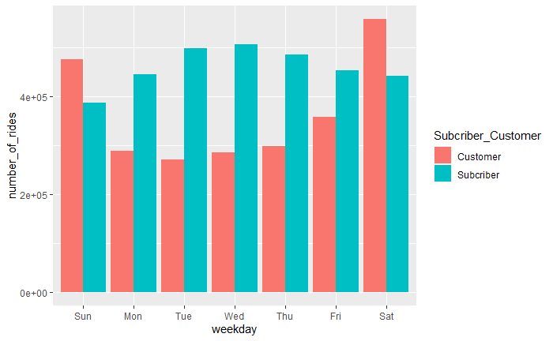

```r
  new_trips_v2 %>%
   mutate(weekday=wday(started_at,label=TRUE))%>%

     group_by(Subcriber_Customer,weekday)%>%

     summarise(number_of_rides = n(),average_duration = mean(ride_length_secs))%>%

     arrange(Subcriber_Customer,weekday)%>%

 ggplot(aes(x = weekday, y = number_of_rides, fill = Subcriber_Customer)) +
    geom_col(position = "dodge")
```

```r
NA
```

# Let’s create a visualization for average duration

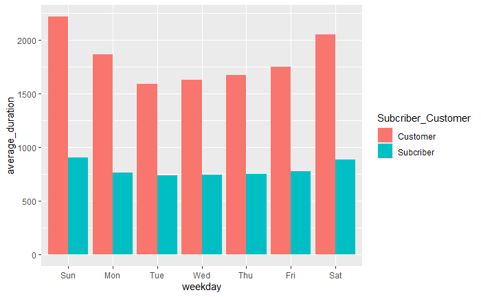

```r
new_trips_v2 %>%
   mutate(weekday=wday(started_at,label=TRUE))%>%

     group_by(Subcriber_Customer,weekday)%>%

     summarise(number_of_rides = n(),average_duration = mean(ride_length_secs))%>%

     arrange(Subcriber_Customer,weekday)%>%

 ggplot(aes(x = weekday, y = average_duration, fill = Subcriber_Customer)) +
    geom_col(position = "dodge")
```

More analysis of the data using charts created with Tableau can be found in my presentation.